# StatComp Project 1: 3D printer materials estimation

Nisha Depala (s2149899)

# 1 The Data

## 1.1 Summary of the data set

A 3D printer uses rolls of filament that get heated and squeezed through a moving nozzle, gradually building objects. The objects are first designed in a CAD program that also estimates how much material will be required to print the object. Each object consists of only one colour.

A table showing the number of data points for each material

| Material | Occurences |
| --- | --- |
| Black | 19 |
| Green | 25 |
| Magenta | 10 |
| Neon blue | 7 |
| Neon pink | 3 |
| Red | 22 |

## 1.2 Variability of CAD weight against different materials

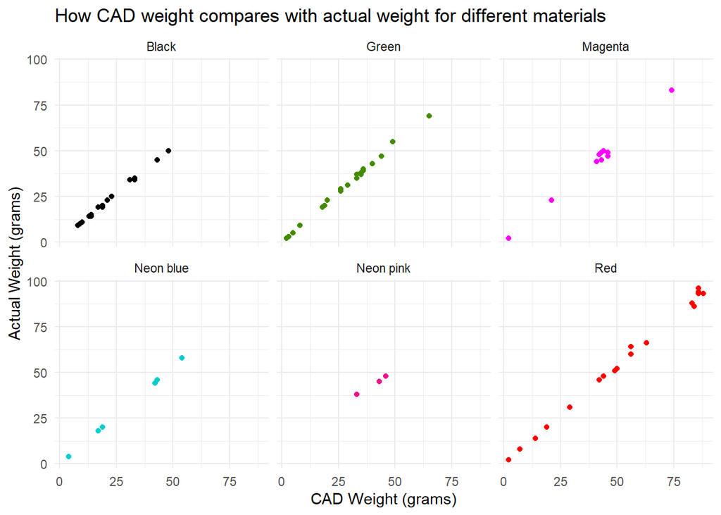

Firstly, looking at our scatter plot, we can see the distribution of the object weight that the CAD software calculated against the actual weight of the object ordered by material. It is evident from the scatter plot that there is not an even distribution of objects printed per material. This makes it hard to assess data trends as there isn’t enough data to make conclusive arguments. Magenta, neon blue and neon pink have 10 or fewer data points. These data points are also largely scattered which does not allow for spotting a trend. Looking at the data points for the rest of the objects, we can see that they all follow a linear relationship, the CAD weight is proportionate to the actual weight.

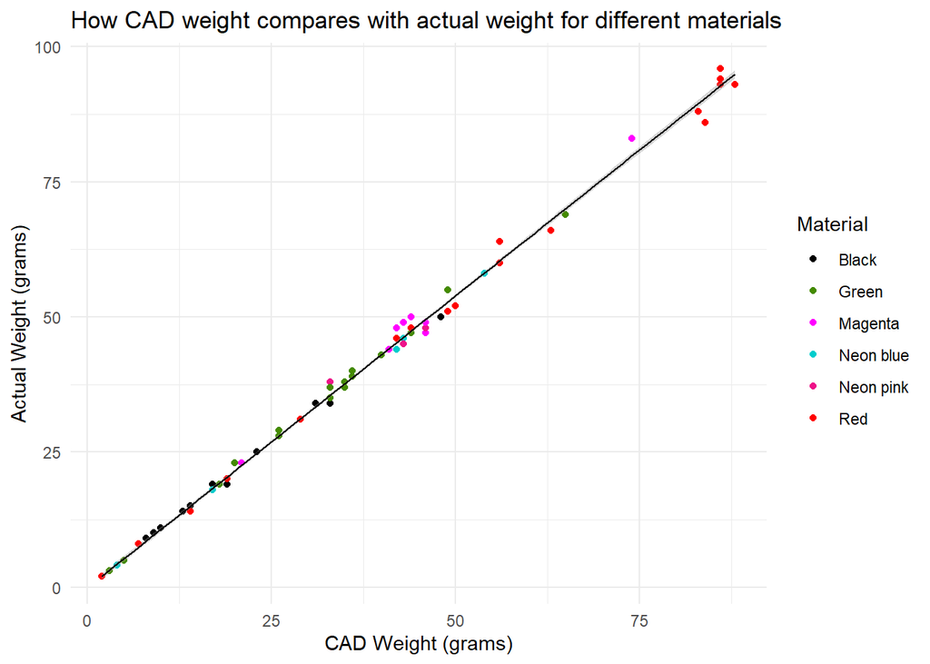

Plotting all of the colours together, we can notice a trend. The line of best fit is given by $y = 1.079855x -0.1097023$. This implies that the relationship is roughly one-to-one between CAD weight and actual weight.

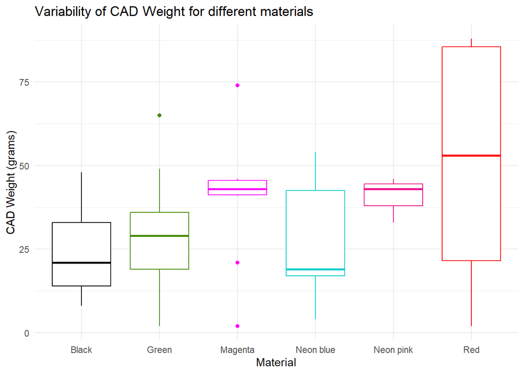

Now, to understand the variability in each material group, we can look at their box plots. The median CAD weight for black materials is smaller than the median for the green and red groups. It is also skewed towards the lower end of the IQR implying that the first 50% of the data is clustered together and as CAD weight increases, there are fewer objects. The green box plot has larger whiskers but a similar IQR to the black boxplot. This indicates that the data is spread wider across its top and bottom 25%. The red box plot has a large IQR and no outliers implying that the data is evenly spread over a wide range.

# 2 Classical estimation

We consider two linear models, A and B, to capture the relationship between CAD weight $(x_i)$ and actual weight $(y_i)$. The models are defined as
$$\text{Model A: } y_i \sim
\text{Normal}[\beta_1 + \beta_2x_i, exp(\beta_3+\beta_4x_i)] \text{ and
Model B: } y_i \sim \text{Normal}[\beta_1 + \beta_2x_i,
exp(\beta_3)+(\beta_4)x_i^2]$$

Model A Parameter Confidence Intervals

|  | Actual | Lower | Upper |
| --- | --- | --- | --- |
| β1 | -0.0893809 | -0.3007731 | 0.1220112 |
| β2 | 1.0792116 | 1.0694721 | 1.0889511 |
| β3 | -1.9026253 | -2.4703628 | -1.3348878 |
| β4 | 0.0556670 | 0.0409975 | 0.0703365 |

As model A assumes an additive error term in the model; the narrow confidence intervals for $\beta_3$ and $\beta_4$ suggest a precise estimation of the additive error terms model A.

Model B Parameter Confidence Intervals

|  | Actual | Lower | Upper |
| --- | --- | --- | --- |
| β1 | -0.1612982 | -0.2215414 | -0.101055 |
| β2 | 1.0828644 | 1.0751668 | 1.090562 |
| β3 | -13.2127829 | -86.3938586 | 59.968293 |
| β4 | -6.6135928 | -6.8644340 | -6.362752 |

Similar to model A, the confidence intervals for $\beta_1$ and $\beta_2$ are relatively narrow, indicating a higher degree of certainty in the estimates of these parameters. $\beta_3$ and $\beta_4$ are significantly wider compared to model A. This implies that we cannot say with great certainty that our estimated parameter is in fact correct.

Model B assumes a relative error term in the model, motivated by the assumption that fluctuations in material properties and room temperature lead to relative errors; the wider confidence intervals for $\beta_3$ and $\beta_4$ indicate greater uncertainty in estimating the parameters associated with the relative error term in Model B.

In summary, while both models provide estimates for the relationship between CAD weight and actual weight, the wider confidence intervals in Model B suggest greater uncertainty in estimating parameters associated with the relative error term, which aligns with the physics-based assumption of the model. Model A, while mathematically convenient, may not fully capture the nature of the errors in the CAD software calculation according to the physics assumptions.

# 3 Bayesian estimation

We now focus on a Bayesian model for describing the actual weight $(y_i)$ based on the CAD weight $(x_i)$ for observation $i$:
$$y_i \sim
\text{Normal} [\beta_1+\beta_2x_i,\beta_3+\beta_4x_i^2].$$

## 3.1 Prior density

The function `log_prior_density()` calculates the logarithm of the joint prior density $p(\boldsymbol{\theta})$ for the four $\theta_i$ parameters. It calculates the priors for each parameter and then returns the sum of them.

## 3.2 Observation likelihood

The function `log_like()` returns the log-likelihood for the model defined above. It takes a parameter vector $\boldsymbol{\theta}$, predictor values $(\mathbf{x})$ and observed response values $(\mathbf{y})$. The function calculates the log-likelihood by summing the logarithms of the normal PDF evaluated at each observed response value. It allows for the evaluation of the goodness of fit of a statistical model and observed data.

## 3.3 Posterior density

The function`log_posterior_density()` calculates the logarithm of the posterior density $p(\boldsymbol{\theta}|\mathbf{y})$ for the Bayesian model detailed above. The posterior density is directly proportional to the likelihood function multiplied by the the prior for the parameters. As we have already defined functions that calculate the logarithm of the prior and the likelihood, we can evaluate the posterior density by summing them. This correct up to some unevaluated normalisation constant.

## 3.4 Posterior mode

The function `posterior_mode()` optimises the log posterior density to find the mode; this represents the most probable values of the parameters given the observed data and prior information and provides an insight into the curvature of the log posterior density through the Hessian. In our case, this is all in reference to our dataset containing information about the 3D printer using rolls of filament.

## 3.5 Gaussian approximation

We can use `posterior_mode()` to evaluate the inverse of the negated Hessian at the mode, in order to obtain a multivariate Normal approximation $\text{Normal}(\boldsymbol{\mu},\mathbf{S})$ to the posterior distribution for $\boldsymbol{\theta}$. Here, $\boldsymbol{\mu}$ is the mode of the log-posterior-density and $\mathbf{S}$ is the inverse of the negated Hessian (covariance matrix).

```r
# Initialise gamma and theta parameters
gamma_i <- rep(1, 4)
theta_i <- rep(0, 4)

# select the predictor and observed variables from the dataset `filament1.rda`
x <- filament1$CAD_Weight
y <- filament1$Actual_Weight

# obtain the mode, hessian and covariance matrix
posterior_mode <- posterior_mode(theta_i, x, y, gamma_i)

mode <- posterior_mode$mode
hessian <- posterior_mode$hessian
covariance_matrix <- posterior_mode$S
```

$$\begin{align}
\boldsymbol{\mu} &= [-0.1008234,1.0800211,-2.9834581,-6.7584316]
\\
\mathbf{S} = \text{covariance matrix} &=
\begin{bmatrix}
0.0082951754 & -0.0003431287 & 0.03033564 &
-0.0042956177 \\
-0.0003431287 & 2.995519e-05 & -0.00149660 &
0.0002120789 \\
0.0303356429 & -0.0014966000 & 1.06644653 &
-0.1239715050 \\
-0.0042956177 & 0.0002120789 & -0.12397151 &
0.0454331418
\end{bmatrix}
\end{align}$$

## 3.6 Importance sampling function

The function `do_importance()` implements the Monte Carlo integration method using a multivariate Normal approximation $\text{Normal}(\boldsymbol{\mu},\mathbf{S})$ as the importance sampling distribution. For each sample, the log-importance weight is calculated by subtracting the log-density of the sample under the multivariate normal distribution from the log-posterior-density evaluated at the sample. These log weights are normalised to sum to 1.

## 3.7 Importance sampling

Let us generate an importance sample of size 10,000 that is randomly generated following the multivariate Normal approximation as the importance sampling distribution. It has a mean of $\mu$, the mode of the log-posterior-density, and standard deviation given by the covariance matrix.

```r
importance_sample <- do_importance(10000, mode, covariance_matrix, x, y, gamma_i)
```

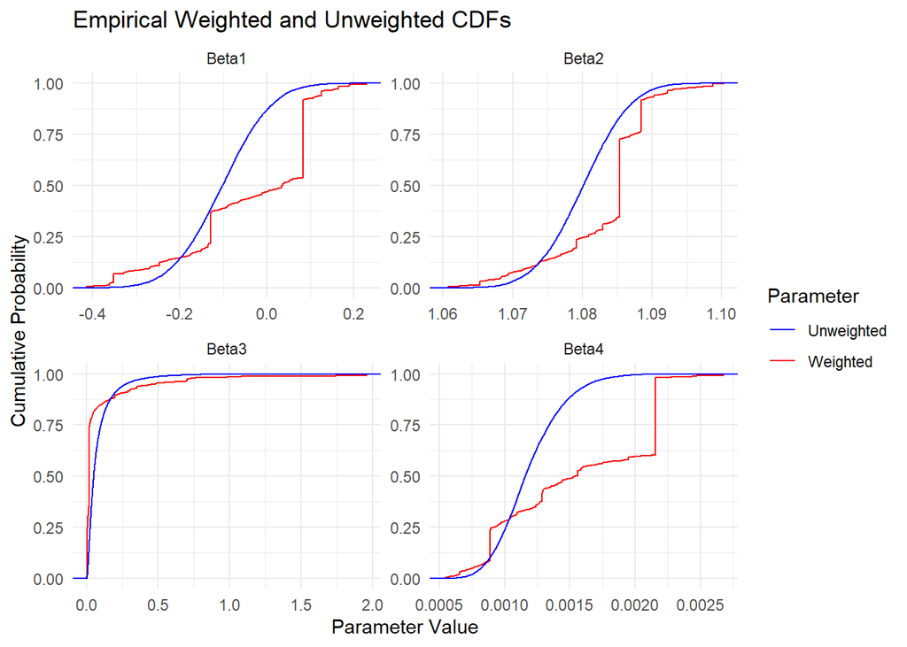

```r
# Compute credible intervals for each parameter
credible_intervals <- importance_sample_pivot %>%
  group_by(Parameter) %>%
  summarise(credible_interval = list(make_CI(Value, exp(log_weights), 0.90))) %>%
  unnest(cols = credible_interval)
```

Credible Intervals for Beta Parameters

| Parameter | Lower | Upper |
| --- | --- | --- |
| Beta1 | -0.3505529 | 0.1246924 |
| Beta2 | 1.0683079 | 1.0918990 |
| Beta3 | 0.0024416 | 0.4470408 |
| Beta4 | 0.0007547 | 0.0021574 |

### 3.7.1 $\beta_1$ and $\beta_2$ analysis

The empirical CDF curve provides insights into the distribution of the sampled $\beta$-values.

The sharp jumps in the weighted cumulative frequency indicate a large cluster of points in these regions. This impacts the cumulative frequency graph by pulling it down in these regions.

Observing the credible intervals in these ranges, we can see that the $\beta_1$ and $\beta_2$ parameters also match the intervals represented by the empirical CDF for a 90% credible interval. A credible interval represents the plausibility that a parameter takes certain values. The credible intervals for $\beta_1$ and $\beta_2$ are relatively narrow, indicating a higher degree of certainty in the estimates of these parameters.

The $\beta_1$ parameter represents the intercept of the model, while $\beta_2$ represents the coefficient of the CAD weight term; it represents the change in the actual weight for a one unit change in the CAD weight. As the $\beta_1$ credible interval contains 0, it may not have a significant effect on how the actual weight changes. This would mean that the relationship between the actual weight and CAD weight is such that the line passes through the origin on a graph. This suggests that the model is based solely on the linear and quadratic terms of $x_i$.

The $\beta_2$ parameter represents the coefficient of the linear term of the CAD weight. It represents the change in the actual weight for a one unit change of the CAD weight. The $\beta_2$ parameter is significant as it is non-zero. The $\beta_2$ parameter is close to 1 for a generated random sample. This indicates that the change in the CAD weight is directly proportional to the change in the actual weight. As we have stated that $\beta_1$ is likely to be negligible, this indicates that the actual weight is modeled solely by $\beta_2$. If we consider this in relation to our data set, it implies that plotting actual weight against CAD weight will lead to a graph that closely follows $y=x$. Looking back to section 1, we can see that this matches the findings from the scatter plot. Our importance sample is generated from that data and thus expanding this to a larger sample size, we can see that the conclusions are still the same. This indicates that the CAD program is accurate in estimating how much material will be required to print the object.

### 3.7.2 $\beta_3$ and $\beta_4$ analysis

If we look at the empirical CDF graph for the $\beta_3$ parameter, we can see that the graph is heavily skewed toward the beginning. The sharp initial jump indicates that there are many data points for the parameter values close to 0. It flattens out very quickly indicating that there are very few data points when the parameter value gets larger. This implies that the parameter value is likely to be close to 0. This is equal to the constant variance in the Normal distribution. Contextually, this is the amount of variation the actual weight will have for the CAD weight. The smaller the CAD weight, the more likely the $\beta_3$ parameter is to have an impact as the CAD weight term will be close to 0. This means that all the variation in the data would be explained by the $\beta_3$ parameter but as $x_i$ gets bigger, it becomes negligible.

The $\beta_4$ parameter is the coefficient of the quadratic term $x_i^2$, the explanatory variable CAD weight. It represents the variance in actual weight for a one unit change in the CAD weight, assuming all other variables are held constant. This has a greater impact when $x_i$ becomes larger. This follows the modelling assumptions in section 2. If we consider it contextually, the printer operator reasons that random fluctuations in the material properties such as density and room temperature should lead to a relative error. This implies that if we are printing larger objects, the printer is being operated for longer which is likely to causes the machine to heat up leading to relative errors. The size of the object also increases the likelihood of error.

The 5th and 95th percentiles on the empirical CDF graphs match the lower and upper credible intervals respectively. The credible intervals have a small width indicating that they have been estimated with a good level of precision and accurately model the sampled data.

As $\beta_3$ and $\beta_4$ have credible intervals that are close to 0, there is likely to be very little variation in the data. This matches the scatter plot in section 1, as the data points all lie very close to the line of best fit. This means that the relative errors are very unlikely to impact the fit of our model and cause the data to deviate.

### 3.7.3 Further Empirical CDF analysis

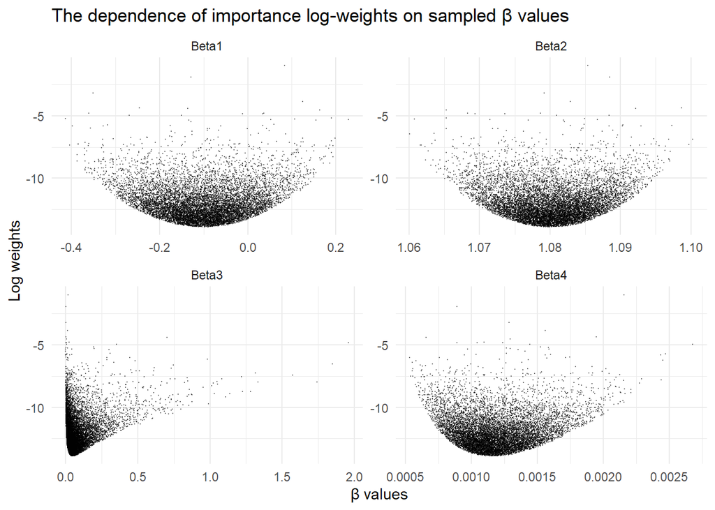

The empirical CDF graphs represent the cumulative distribution of the data points. From the above graphs, we can see that the distribution of data points matches the empirical CDF graphs. For $\beta_1$, $\beta_2$ and $\beta_4$ have an S-shaped curve which implies that the points are evenly distributed which matches the analysis above and the log weights graphs. The $\beta_3$ graph is clustered around the beginning which also matches its ECDF albeit different to the other examples. This further supports that the modelling techniques used to sample the data have been accurate.

### 3.7.4 Summary

From above, we have observed that $\beta_1$, $\beta_3$ and $\beta_4$ are negligible. This means that the 3D printer application is largely based on the $\beta_2$ parameter alone. This implies that the actual weight is modeled by the $\beta_2$ parameter multiplied by the CAD weight.

In summary, the Bayesian model offers a probabilistic framework for parameter estimation, enabling the characterization of uncertainty in parameter estimates and predictions. For the 3D printer application, these results help in understanding the relationship between CAD weight and actual weight for a larger importance sample.

# 4 Code appendix

```r
#' Nisha, Depala
#' Add your own function definitions on this file.

#' Log-Exponential density
#'
#' Compute the density or log-density for a Log-Exponential (LogExp)
#' distribution
#'
#' @param x vector of quantiles
#' @param rate vector of rates
#' @param log logical; if TRUE, the log-density is returned

dlogexp <- function(x, rate = 1, log = FALSE) {
  result <- log(rate) + x - rate * exp(x)
  if (!log) {
    exp(result)
  }
  result
}

#' Log-Sum-Exp
#'
#' Convenience function for computing log(sum(exp(x))) in a
#' numerically stable manner
#'
#' @param x numerical vector

log_sum_exp <- function(x) {
  max_x <- max(x, na.rm = TRUE)
  max_x + log(sum(exp(x - max_x)))
}


#' wquantile
#'
#' Calculates empirical sample quantiles with optional weights, for given probabilities.
#' Like in quantile(), the smallest observation corresponds to a probability of 0 and the largest to a probability of 1.
#' Interpolation between discrete values is done when type=7, as in quantile().
#' Use type=1 to only generate quantile values from the raw input samples.
#'
#' @param x numeric vector whose sample quantiles are wanted
#' NA and NaN values are not allowed in numeric vectors unless na.rm is TRUE
#' @param probs numeric vector of probabilities with values in [0,1]
#' @param na.rm logical; if true, any NA and NaN's are removed from x before the quantiles are computed
#' @param type numeric, 1 for no interpolation, or 7, for interpolated quantiles. Default is 7
#' @param weights    numeric vector of non-negative weights, the same length as x, or NULL. The weights are normalised to sum to 1. If NULL, then wquantile(x) behaves the same as quantile(x), with equal weight for each sample value

wquantile <- function (x, probs = seq(0, 1, 0.25), na.rm = FALSE, type = 7,
                       weights = NULL, ...)
{
  if (is.null(weights) || (length(weights) == 1)) {
    weights <- rep(1, length(x))
  }
  stopifnot(all(weights >= 0))
  stopifnot(length(weights) == length(x))
  if (length(x) == 1) {
    return(rep(x, length(probs)))
  }
  n <- length(x)
  q <- numeric(length(probs))
  reorder <- order(x)
  weights <- weights[reorder]
  x <- x[reorder]
  wecdf <- pmin(1, cumsum(weights)/sum(weights))
  if (type == 1) {
  }
  else {
    weights2 <- (weights[-n] + weights[-1])/2
    wecdf2 <- pmin(1, cumsum(weights2)/sum(weights2))
  }
  for (pr_idx in seq_along(probs)) {
    pr <- probs[pr_idx]
    if (pr <= 0) {
      q[pr_idx] <- x[1]
    }
    else if (pr >= 1) {
      q[pr_idx] <- x[n]
    }
    else {
      if (type == 1) {
        j <- 1 + pmax(0, pmin(n - 1, sum(wecdf <= pr)))
        q[pr_idx] <- x[j]
      }
      else {
        j <- 1 + pmax(0, pmin(n - 2, sum(wecdf2 <= pr)))
        g <- (pr - c(0, wecdf2)[j])/(wecdf2[j] - c(0,
                                                   wecdf2)[j])
        q[pr_idx] <- (1 - g) * x[j] + g * x[j + 1]
      }
    }
  }
  q
}

#' Compute empirical weighted cumulative distribution
#'
#' Version of `ggplot2::stat_ecdf` that adds a `weights` property for each
#' observation, to produce an empirical weighted cumulative distribution function.
#' The empirical cumulative distribution function (ECDF) provides an alternative
#' visualisation of distribution. Compared to other visualisations that rely on
#' density (like [geom_histogram()]), the ECDF doesn't require any
#' tuning parameters and handles both continuous and discrete variables.
#' The downside is that it requires more training to accurately interpret,
#' and the underlying visual tasks are somewhat more challenging.
#'
# @inheritParams layer
# @inheritParams geom_point
#' @param na.rm If `FALSE` (the default), removes missing values with
#'    a warning.  If `TRUE` silently removes missing values.
#' @param n if NULL, do not interpolate. If not NULL, this is the number
#'   of points to interpolate with.
#' @param pad If `TRUE`, pad the ecdf with additional points (-Inf, 0)
#'   and (Inf, 1)
#' @section Computed variables:
#' \describe{
#'   \item{x}{x in data}
#'   \item{y}{cumulative density corresponding x}
#' }
#' @seealso wquantile
#' @export
#' @examples
#' library(ggplot2)
#'
#' n <- 100
#' df <- data.frame(
#'   x = c(rnorm(n, 0, 10), rnorm(n, 0, 10)),
#'   g = gl(2, n),
#'   w = c(rep(1/n, n), sort(runif(n))^sqrt(n))
#' )
#' ggplot(df, aes(x, weights = w)) + stat_ewcdf(geom = "step")
#'
#' # Don't go to positive/negative infinity
#' ggplot(df, aes(x, weights = w)) + stat_ewcdf(geom = "step", pad = FALSE)
#'
#' # Multiple ECDFs
#' ggplot(df, aes(x, colour = g, weights = w)) + stat_ewcdf()
#' ggplot(df, aes(x, colour = g, weights = w)) +
#'   stat_ewcdf() +
#'   facet_wrap(vars(g), ncol = 1)

stat_ewcdf <- function(mapping = NULL, data = NULL,
                       geom = "step", position = "identity",
                       ...,
                       n = NULL,
                       pad = TRUE,
                       na.rm = FALSE,
                       show.legend = NA,
                       inherit.aes = TRUE) {
  ggplot2::layer(
    data = data,
    mapping = mapping,
    stat = StatEwcdf,
    geom = geom,
    position = position,
    show.legend = show.legend,
    inherit.aes = inherit.aes,
    params = list(
      n = n,
      pad = pad,
      na.rm = na.rm,
      ...
    )
  )
}


#' @title StatEwcdf ggproto object
#' @name StatEwcdf
#' @rdname StatEwcdf
#' @aliases StatEwcdf
#' @format NULL
#' @usage NULL
#' @export
#' @importFrom ggplot2 aes after_stat has_flipped_aes Stat
NULL

StatEwcdf <- ggplot2::ggproto(
  "StatEwcdf", ggplot2::Stat,
  required_aes = c("x|y", "weights"),
  dropped_aes = c("weights"),

  default_aes = ggplot2::aes(y = ggplot2::after_stat(y)),

  setup_params = function(data, params) {
    params$flipped_aes <-
      ggplot2::has_flipped_aes(data,
                               params,
                               main_is_orthogonal = FALSE,
                               main_is_continuous = TRUE)

    has_x <- !(is.null(data$x) && is.null(params$x))
    has_y <- !(is.null(data$y) && is.null(params$y))
    if (!has_x && !has_y) {
      rlang::abort("stat_ewcdf() requires an x or y aesthetic.")
    }
    has_weights <- !(is.null(data$weights) && is.null(params$weights))
    #    if (!has_weights) {
    #      rlang::abort("stat_ewcdf() requires a weights aesthetic.")
    #    }
```

```r
    params
  },

  compute_group = function(data, scales, n = NULL, pad = TRUE, flipped_aes = FALSE) {
    data <- flip_data(data, flipped_aes)
    # If n is NULL, use raw values; otherwise interpolate
    if (is.null(n)) {
      x <- unique(data$x)
    } else {
      x <- seq(min(data$x), max(data$x), length.out = n)
    }

    if (pad) {
      x <- c(-Inf, x, Inf)
    }
    if (is.null(data$weights)) {
      data_ecdf <- ecdf(data$x)(x)
    } else {
      data_ecdf <-
        spatstat.geom::ewcdf(
          data$x,
          weights = data$weights / sum(abs(data$weights))
        )(x)
    }

    df_ecdf <- vctrs::new_data_frame(list(x = x, y = data_ecdf), n = length(x))
    df_ecdf$flipped_aes <- flipped_aes
    ggplot2::flip_data(df_ecdf, flipped_aes)
  }
)

### Classical Estimation

#' neg_log_like
#'
#' Compute the negative log likelihood for a specified model, either A or B that
#' follows:
#' Model A: yi ∼ Normal(β1 + β2xi, exp(β3 + β4xi))
#' Model B: yi ∼ Normal(β1 + β2xi, exp(β3) + exp(β4)xi^2))
#'
#' @param beta a numeric vector of model parameters
#' @param data a data.frame containing the required variables
#' @param model either A or B
#' @returns the negated log-likelihood for the specified model

neg_log_like <- function(beta, data, model) {

  xi = data$CAD_Weight
  yi = data$Actual_Weight

  if (model == "A"){
    mu = beta[1] + beta[2]*xi
    var <- exp(beta[3] + beta[4]*xi)
  } else if (model == "B") {
    mu <- beta[1] + beta[2]*xi
    var <- exp(beta[3]) + exp(beta[4])*xi^2
  }

  neg_llike <- -sum(dnorm(x = yi, mean = mu, sd = sqrt(var), log = TRUE))

  return(neg_llike)
}

#' filament_1_estimate
#'
#' @param data a data frame with columns CAD_Weight and Actual_Weight
#' @param model the model choice (either A or B)
#' @returns a data frame the best set of parameters, their confidence intervals and and the Hessian

filament1_estimate <- function(data, model){

  if (model == "A"){
    betaA <- c(-0.1, 1.07, -2, 0.05) # initial values for (β1, β2, β3, β4)
    opt <- optim(par = betaA, fn = neg_log_like, data = data, model = model, hessian = TRUE)
  } else if (model == "B") {
    betaB <- c(-0.15, 1.07, -13.5, -6.5)  # initial values for (β1, β2, β3, β4)
    opt <- optim(par = betaB, fn = neg_log_like, data = data, model = model, hessian = TRUE)
  }

  parameters <- opt$par
  hessian <- opt$hessian
  df <- list("parameters" = parameters, "hessian" = hessian)

  z_alpha <- qnorm(1 - 0.1 / 2)
  se <- sqrt(diag(solve(hessian)))
  Parameter <- parameters
  Actual <- parameters
  Lower <- parameters - z_alpha * se
  Upper  <- parameters + z_alpha * se

  return(data.frame(Actual, Lower, Upper))
}


### Bayesian Estimation


#' log_prior_density
#'
#' @param theta a numeric vector equal to θ parameters
#' @param params a numeric vector of γ parameters
#'
#' @returns the logarithm of the joint prior density p(θ) for the four θi parameters
#'
#' @examples
#' theta <- c(0, 0, 0, 0)
#' params <- c(1, 1, 1, 1)
#' log_prior_density(theta, params)

log_prior_density <- function(theta, params) {

  prior_t1 <- dnorm(theta[1], mean = 0, sd = sqrt(params[1]), log = TRUE)
  prior_t2 <- dnorm(theta[2], mean = 1, sd = sqrt(params[2]), log = TRUE)
  prior_t3 <- dlogexp(theta[3], rate = params[3], log = TRUE)
  prior_t4 <- dlogexp(theta[4], rate = params[4], log = TRUE)

  return(prior_t1 + prior_t2 + prior_t3 + prior_t4)
}

#' log_like
#'
#' @param theta a numeric vector equal to θ parameters
#' @param x a numeric vector of x values as defined in the model
#' @param y a numeric vector of y values as defined in the model
#'
#' @returns the log likelihood for the model defined above
#'
#' @example
#' x <- seq(100)
#' y <- seq(100)
#' log_like(c(0,0,0,0), x, y)

log_like <- function(theta, x, y) {

  mu = theta[1] + theta[2]*x
  var = exp(theta[3]) + exp(theta[4])*x^2

  llike = sum(dnorm(y, mean = mu, sd = sqrt(var), log = TRUE))

  return(llike)
}

#' log_posterior_density
#'
#' This function calculates the logarithm of the posterior density p(θ|y) for the Bayesian model,
#' where θ represents the parameter vector, based on observed data x and y, and given γ parameters.
#'
#' @param theta a numeric vector equal to θ parameters
#' @param x a numeric vector of predictor x values as defined in the model
#' @param y a numeric vector of observed y values as defined in the model
#' @param params a numeric vector of γ parameters
#'
#' @returns the logarithm of the posterior density p(θ|y), apart from some
#' unevaluated normalisation constant
#'
#' @seealso log_prior_density, log_like
#'
#' @examples
#' # Compute log posterior density for given parameters and data
#' log_posterior_density(c(0.1, 0.2, -1.5, 0.5), x_data, y_data, c(1, 1, 1, 1))

log_posterior_density <- function(theta, x, y, params) {

  prior = log_prior_density(theta, params)
  llike = log_like(theta, x, y)

  return(llike + prior)
}

#' posterior_mode
#'
#' @param theta_start initial values of (θ1, θ2, θ3, θ4)
#' @param x a numeric vector of predictor x values as defined in the model
#' @param y a numeric vector of observed y values as defined in the model
#' @param params a numeric vector of γ parameters
#'
#' @returns a list containing the posterior mode location, the Hessian of the
#' log density at the mode and the inverse of the negated Hessian at the mode
#'
#' @seealso log_posterior_density

posterior_mode <- function(theta_start, x, y, params) {

  opt<- optim(theta_start, log_posterior_density, x = x, y = y, params = params, method = "BFGS", control = list(fnscale = -1), hessian = TRUE)

  parameters <- opt$par
  hessian <- opt$hessian

  return(list("mode" = parameters, "hessian" = hessian, "S" = solve(-hessian)))
}

#' do_importance
#'
#' This function generates samples from a multivariate normal distribution and
#' computes the normalised log-importance weights based on the parameters and
#' data. The function outputs a data frame containing the samples and their
#' corresponding normalized log-importance-weights.
#'
#' @param N the number of samples to generate
#' @param mu a numeric vector of the mean for the importance distribution.
#' @param S the covariance matrix for the importance distribution.
#' @param x a numeric vector of predictor x values as defined in the model
#' @param y a numeric vector of observed y values as defined in the model
#' @param params a numeric vector of γ parameters
#'
#' @returns a data frame with the beta values and the normalised log importance
#' weights
#'
#' @seealso log_posterior_density, log_sum_exp
#'
#' @example
#' # Generate importance samples with N = 10000
#' do_importance(10000, c(0, 0, 0, 0), diag(4), x_data, y_data, c(1, 1, 1, 1))
```

```r
do_importance <- function(N, mu, S, x, y, params) {

  samples <- rmvnorm(n = N, mean = mu, sigma = S)

  log_weights <- log_posterior_density(samples, x, y, params) - dmvnorm(samples, mean = mu, sigma = S, log = TRUE)

  normalise_log_weights <- log_weights - log_sum_exp(log_weights)

  Beta1 = samples[, 1]
  Beta2 = samples[, 2]
  Beta3 = exp(samples[, 3])
  Beta4 = exp(samples[, 4])

  B_i <- cbind(Beta1, Beta2, Beta3, Beta4, log_weights = normalise_log_weights)

  return(data.frame(B_i))
}

#' make_CI
#'
#' This function creates confidencene intervals given predictor x values and
#' a confidence interval
#'
#' @param x a numeric vector of predictor x values as defined in the model
#' @param weights a numeric vector of weights from the samples
#' @param prob number that represents the credible interval we are looking for
#'
#' @returns a data frame containing the upper and lower bounds of the credible interval
#'
#' @seealso wquantile
#'
#' @examples
#' make_CI(Value, exp(log_weights), 0.90)

make_CI <- function(x, weights, prob) {

  quantiles <- wquantile(x, probs = c((1 - prob) / 2, 1 - (1 - prob) / 2), weights = weights)
  CI <- data.frame(Lower = quantiles[[1]], Upper = quantiles[[2]])

  return(CI)
}
```